# Sentiment Analysis - Jules Verne Novels

Coffy Andrews-Guo, Krutika Patel

31 October, 2021

## The `sentiments` datasets

The function `get_sentiments() allows us to get specific sentiment lexicons with the appropriate measures for each one.

```r
library(tidytext)

get_sentiments("afinn")
```

```r
library(tidytext)
get_sentiments("bing")
```

```
## # A tibble: 6,786 x 2
##    word        sentiment
##    <chr>       <chr>
##  1 2-faces     negative
##  2 abnormal    negative
##  3 abolish     negative
##  4 abominable  negative
##  5 abominably  negative
##  6 abominate   negative
##  7 abomination negative
##  8 abort       negative
##  9 aborted     negative
## 10 aborts      negative
## # ... with 6,776 more rows
```

```r
get_sentiments("nrc")
```

## Additional sentiment lexicon `syuzhet`.

The Syuzhet lexicon is part of the Syuzhet package developed by Matthew Jockers. The lexicon was developed in the Nebraska Literary Lab and contains 10,748 words which are assigned a score of -1 to 1 with 16 gradients (Jockers and Thalken 2020). As seen in the descriptive statistics below, the mean is -0.213. Referenced from [BookDown.org](https://www.bookdown.org/psonkin18/berkshire/sentiment.html#limitations-with-bag-of-words-approach)

```r
library(syuzhet)
```

```r
syuzhet <- get_sentiment_dictionary("syuzhet") #get lexicon and create dataframe
#descriptive statistics
summary(syuzhet)
```

```
##      word               value
##  Length:10748       Min.   :-1.000
##  Class :character   1st Qu.:-0.750
##  Mode  :character   Median :-0.400
##                     Mean   :-0.213
##                     3rd Qu.: 0.400
##                     Max.   : 1.000
```

## Load required libraries

```r
library(gutenbergr)
library(dplyr)
```

```r
library(ggplot2)
library(tidyr)
library(wordcloud)
library(reshape2)
library(stringr)
```

## Extract from Gutemburg Project: Jules Verne Collection

Jules Vernes six novels: Around the World in Eighty Days, A Journey to the Center of the Earth, Five Weeks in a Balloon, Abandoned, The Mysterious Island, The Mysterious Island, and The Master of the World. Vernes is a French author whose novels are considered a literary prize based on his imagination, and the innovations and inventions during the late 18th century. The novels were used in motion pictures, stage performances and television based on concepts of submarines, space travel and deep-sea exploration.

```r
world <- gutenberg_download(103)    # Adventure stories/Fiction/Jan 1, 1994
```

```
## Determining mirror for Project Gutenberg from http://www.gutenberg.org/robot/harvest
```

```
## Using mirror http://aleph.gutenberg.org
```

```r
names(world) <- c("book", "text")
world$book <- "Around the World in Eighty Days"

journey <- gutenberg_download(18857)  # Adventure stories/Fiction/Jul 18, 2006
names(journey) <- c("book", "text")
journey$book <- "A Journey to the Center of the Earth"

balloon <- gutenberg_download(3526)  # Adventure/Fiction/Nov 1, 2002
names(balloon) <- c("book", "text")
balloon$book <- "Five Weeks in a Balloon"

aband <- gutenberg_download(33516)  # Castaways/Fiction/Aug 23, 2010
names(aband) <- c("book", "text")
aband$book <- "Abandoned"

island <- gutenberg_download(1268)  # Castaways/Fiction/Apr 1, 1998
names(island) <- c("book", "text")
island$book <- "The Mysterious Island"

master <- gutenberg_download(3809)  #Adventure/Fiction/Mar 1, 2003
names(master) <- c("book", "text")
master$book <- "The Master of the World"
```

Create a single data set and save into RData File

```r
alljvernebooks <- rbind(world, journey, balloon, aband, island, master)
alljvernebooks <- alljvernebooks[alljvernebooks$text!="",]
alljvernebooks$text <- gsub( '[[:punct:]] | [[:digit:]]', '', alljvernebooks$text)

rm(world, journey, balloon, aband, island, master)

# establishing a Rdata file due to difficulty creating a corpus package with corpus functions
save(list = ls(), file = "alljvernebooks.Rdata")
```

## Sentiment analysis with inner join

Load the New Data Set, Clean and Separate Words

```r
load("alljvernebooks.Rdata")
cleanjvernebks <- alljvernebooks %>%
  group_by(book) %>%
  mutate(linenumber = row_number(),
         chapter = cumsum(str_detect(text,
                                     regex("^chapter [\\divxlc]",
                                           ignore_case = TRUE)))) %>%
  ungroup() %>%
  unnest_tokens(word, text)
```

Remove stop words that are not useful for an analysis, typically extremely common words such as “the”, “of”, “to”, and so forth in English.

```r
data("stop_words")
cleanjverne <- cleanjvernebks %>%
  anti_join(stop_words)
```

First, let’s use the NRC lexicon and filter() for the joy words.

```
## # A tibble: 208 x 2
##    word        n
##    <chr>   <int>
##  1 found      62
##  2 journey    36
##  3 hope       20
##  4 honest     16
##  5 fortune    15
##  6 money      15
##  7 true       15
##  8 reward     12
##  9 gain       10
## 10 perfect    10
## # ... with 198 more rows
```

To get a good estimate of sentiment we’ll use 80 lines from each book to wash out narrative structure.

```r
# Next, we count up how many positive and negative words there are in defined sections of each book.
fiction_sentiment <- cleanjverne %>%
  inner_join(get_sentiments("bing")) %>%
  count(book, index = linenumber %/% 80, sentiment) %>%
  pivot_wider(names_from = sentiment, values_from = n, values_fill = 0) %>%
  mutate(sentiment = positive - negative)
```

Plot the sentiments scores

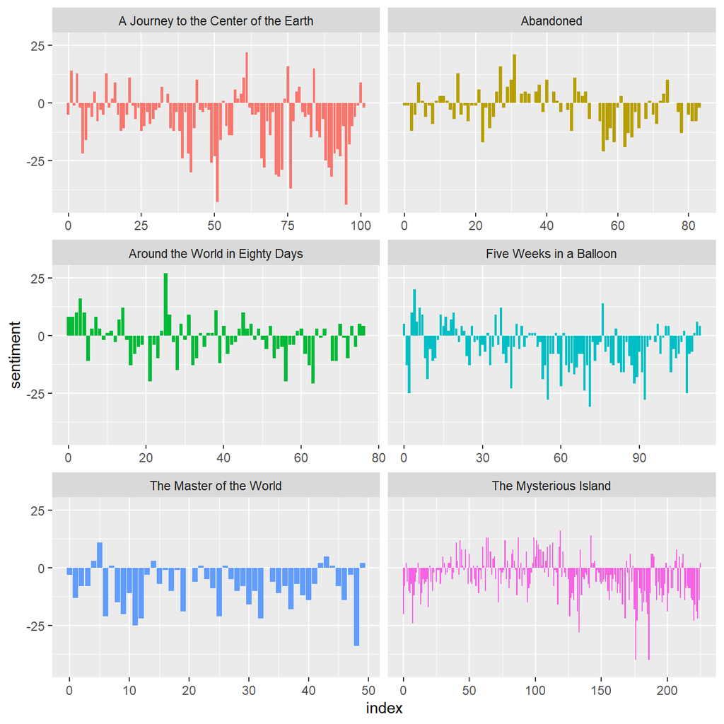

Sentiment through the narratives of Jules Verne’ novels

```r
# Now we can plot these sentiment scores across the plot trajectory of each novel.

library(ggplot2)

ggplot(fiction_sentiment, aes(index, sentiment, fill = book)) +
  geom_col(show.legend = FALSE) +
  facet_wrap(~book, ncol = 2, scales = "free_x")
```

The plot of each novel changes toward more negative or positive sentiment over the trajectory of the story.

## Comparing the three sentiment dictionaries

```r
jour_center <- cleanjverne %>%
  filter(book == "A Journey to the Center of the Earth")

jour_center
```

```
## # A tibble: 31,936 x 4
##    book                                 linenumber chapter word
##    <chr>                                     <int>   <int> <chr>
##  1 A Journey to the Center of the Earth          1       0 journey
##  2 A Journey to the Center of the Earth          1       0 centre
##  3 A Journey to the Center of the Earth          1       0 earth
##  4 A Journey to the Center of the Earth          2       0 jules
##  5 A Journey to the Center of the Earth          2       0 verne
##  6 A Journey to the Center of the Earth          3       0 redactor's
##  7 A Journey to the Center of the Earth          3       0 notejourney
##  8 A Journey to the Center of the Earth          3       0 centre
##  9 A Journey to the Center of the Earth          3       0 earth
## 10 A Journey to the Center of the Earth          4       0 v002
## # ... with 31,926 more rows
```

Using the inner_join() to calculate the sentiment in different ways.

An estimate of the net sentiment (positive - negative) in each chunk of the novel text for each sentiment lexicon.

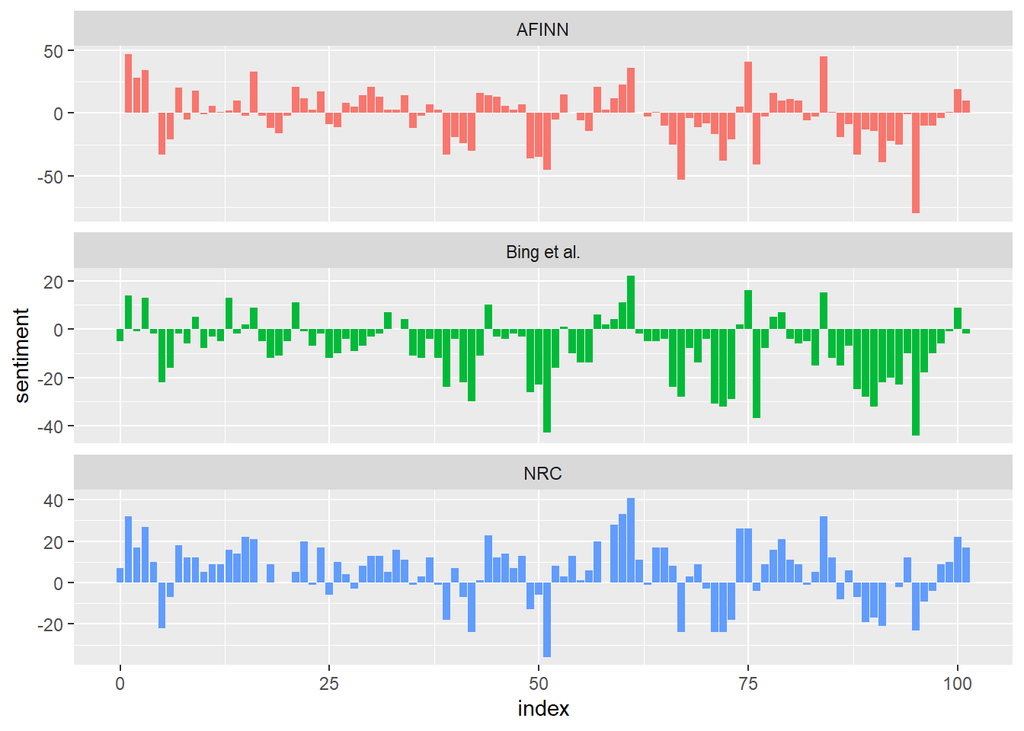

```r
# Let’s bind them together and visualize them
bind_rows(afinn,
          bing_and_nrc) %>%
  ggplot(aes(index, sentiment, fill = method)) +
  geom_col(show.legend = FALSE) +
  facet_wrap(~method, ncol = 1, scales = "free_y")
```

## Additonal Sentiment Lexicon: Syuzhet

Combing Syuzhet lexicon with Julves Vernes Corpus

```r
syuz_jvernes <- cleanjverne %>%      #creates new dataframe "syuz_jvernes"
  inner_join(syuzhet, by = "word") #just joins words in syuzhet
syuz_jvernes
```

```
## # A tibble: 37,901 x 5
##    book                            linenumber chapter word        value
##    <chr>                                <int>   <int> <chr>       <dbl>
##  1 Around the World in Eighty Days          5       0 accept        1
##  2 Around the World in Eighty Days          6       0 convinced     0.6
##  3 Around the World in Eighty Days          6       0 found         0.6
##  4 Around the World in Eighty Days          6       0 ideal         1
##  5 Around the World in Eighty Days          7       0 dear          0.5
##  6 Around the World in Eighty Days         10       0 natural       0.6
##  7 Around the World in Eighty Days         10       0 impatience   -0.5
##  8 Around the World in Eighty Days         11       0 uselessness  -0.6
##  9 Around the World in Eighty Days         12       0 prudent       0.5
## 10 Around the World in Eighty Days         13       0 prove         0.6
## # ... with 37,891 more rows
```

Calculate syuzhet sentiment by book. Syuzhet assigns each word a sentiment score from -1 to +1

```r
#sentiment by year
syuz_jvernes_book <- syuz_jvernes %>%
  group_by(book) %>%
  summarise(syuzhet = sum(value)) %>%
  ungroup()
syuz_jvernes_book
```

```
## # A tibble: 6 x 2
##   book                                 syuzhet
##   <chr>                                  <dbl>
## 1 A Journey to the Center of the Earth   -78.6
## 2 Abandoned                              188.
## 3 Around the World in Eighty Days        122.
## 4 Five Weeks in a Balloon                -29.4
## 5 The Master of the World               -198.
## 6 The Mysterious Island                  -51.5
```

The following chart shows Syuzhet sentiment score for each of the 6 books. The sentiment is mostly negative for the collection where the only `Abandoned` has the highest sentiment score (188.45) and `The Master of the World` has the highest negative sentiment score (-197.80).

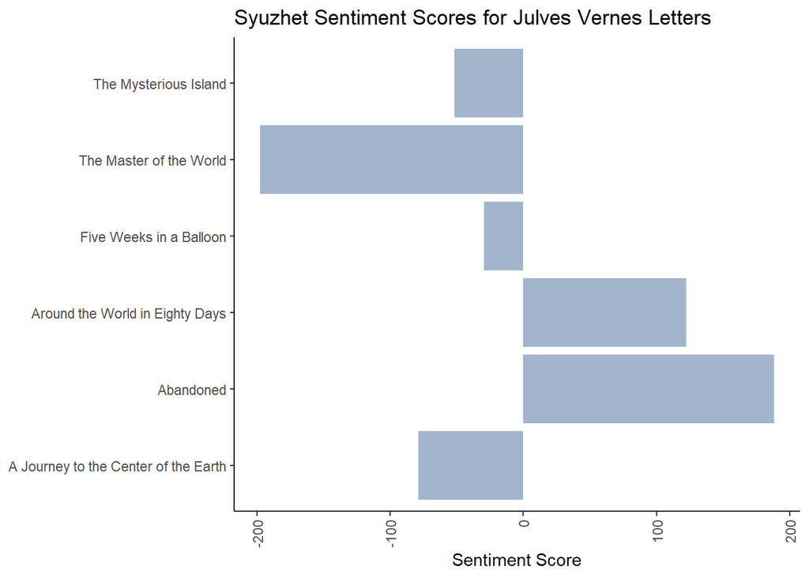

```r
g_syuzhet <- ggplot(syuz_jvernes_book, aes(book, syuzhet)) +
  geom_col(show.legend = FALSE, fill = "lightsteelblue3") +
  labs(x= NULL,y="Sentiment Score",
       title="Syuzhet Sentiment Scores for Julves Vernes Letters")+
  theme_classic() +
  theme(axis.text.x = element_text(angle = 90, vjust = 0.5, hjust = 1))
g_syuzhet +
  coord_flip()
```

## Most common positive and negative words

```r
bing_word_counts <- cleanjverne %>%
  inner_join(get_sentiments("bing")) %>%
  count(word, sentiment, sort = TRUE) %>%
  ungroup()
bing_word_counts
```

```
## # A tibble: 2,326 x 3
##    word       sentiment     n
##    <chr>      <chr>     <int>
##  1 master     positive    210
##  2 top        positive    198
##  3 doubt      negative    177
##  4 impossible negative    172
##  5 scarcely   negative    164
##  6 wild       negative    163
##  7 lost       negative    159
##  8 terror     negative    157
##  9 ready      positive    151
## 10 fell       negative    145
## # ... with 2,316 more rows
```

Visualization with ggplot2

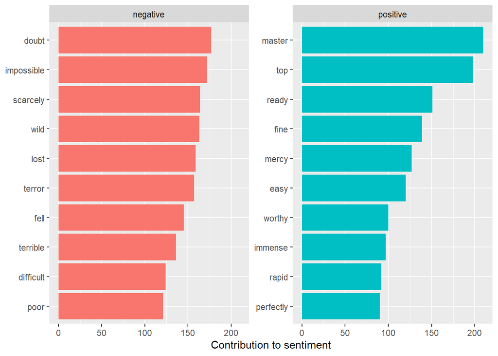

```r
# This can be shown visually, and we can pipe straight into ggplot2
bing_word_counts %>%
  group_by(sentiment) %>%
  slice_max(n, n = 10) %>%
  ungroup() %>%
  mutate(word = reorder(word, n)) %>%
  ggplot(aes(n, word, fill = sentiment)) +
  geom_col(show.legend = FALSE) +
  facet_wrap(~sentiment, scales = "free_y") +
  labs(x = "Contribution to sentiment",
       y = NULL)
```

## Wordclouds

Wordcloud package, which uses base R graphics,it looks at the most common words in Julves Vernes’s works as a whole again, but this time as a wordcloud.

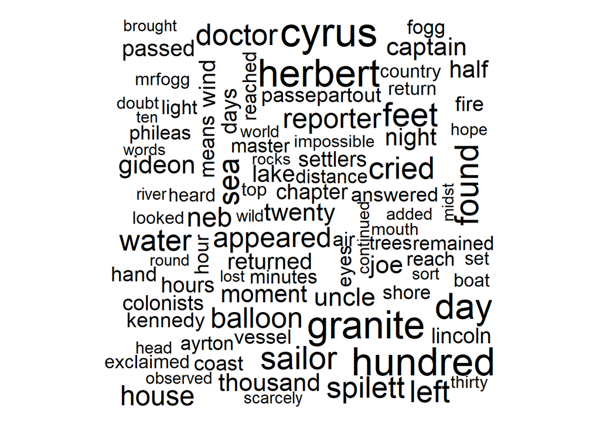

The most common words in Julves Vernes’s novels

## Using comparison.cloud()

Turn the data frame into a matrix with reshape2’s acast(). Perform the sentiment analysis to tag positive and negative words using an inner join, then find the most common positive and negative words.

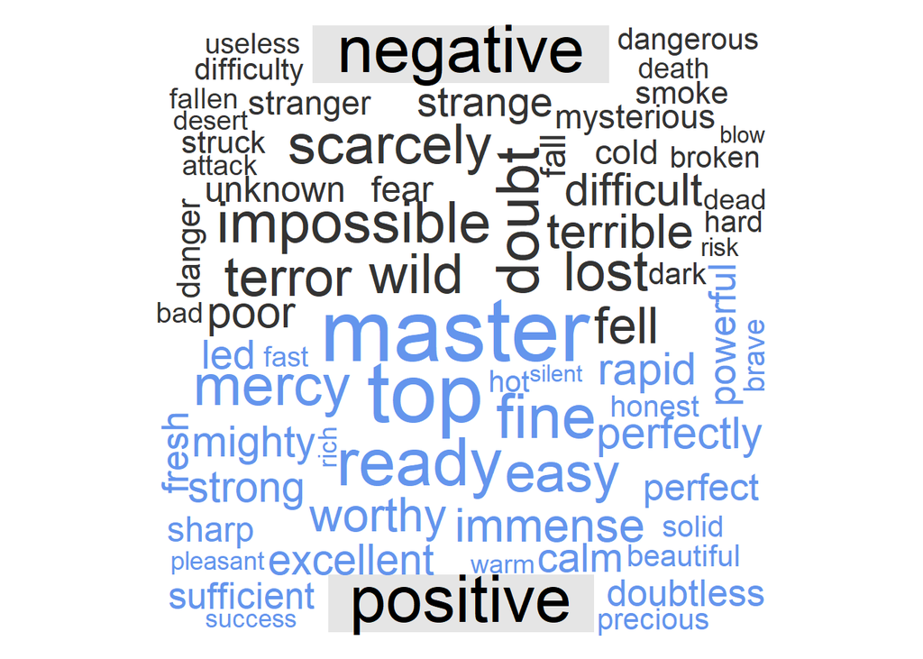

## Conclusion

Using the Syuzhet lexicon and the Jules Vernes books corpus we were able to analysis the overall sentiment of each of his six books. The books had a higher negative sentiment. With the Syuzhet lexicon, 4 out of the 6 books had a net negative sentiment score. Analysis with the AFFIN, Bing et. al, and NRC sentiment lexicon shows two of the three giving a net negative score. The books are meant to be adventurous and innovative. Thus, the word usage is not meant to be overly positive. The world cloud shows a picture of the top words in both the positive and negative direction. The negatively associated words seem to match the books theme. The net negative sentiment analysis leads us to believe that although Jules Vernes’ books aren’t overly positive, they do not fall on a largely negative scale either.

## References:

Robinson, J. S. and D. (n.d.). Welcome to Text Mining with R | Text Mining with R. In www.tidytextmining.com. https://www.tidytextmining.com/index.html

Project Gutenberg. (n.d.). Project Gutenberg. https://www.gutenberg.org/ebooks/

Jockers, M. (2017, December 13). Introduction to the Syuzhet Package. R-Project.org. https://cran.r-project.org/web/packages/syuzhet/vignettes/syuzhet-vignette.html